# Importación de datos

Sesión 2

Luis F. Gomez L.

luis.gomezl@unimilitar.edu.co

Facultad de Estudios a Distancia

2026-11-03

# Preliminares

- Verificar:
  - ¿La carpeta `data` fue creada?
  - ¿El archivo `2021-2024_saber-pro-genericas_faedis_ajustado.rds` fue incluído en `data`?
- Generar carpetas:
  - `015_importar-datos-gpkg-en-r`
    - Crear archivo `001_importar-datos-formato-gpkg.R`
- Instalar paquetes:
  - `install.packages("janitor")`
- Descargar datos:
  - `nivel-departamento_version-mgn-2025_geopackage.gpkg`
    - Agregar en `data`

# Mapa coroplético

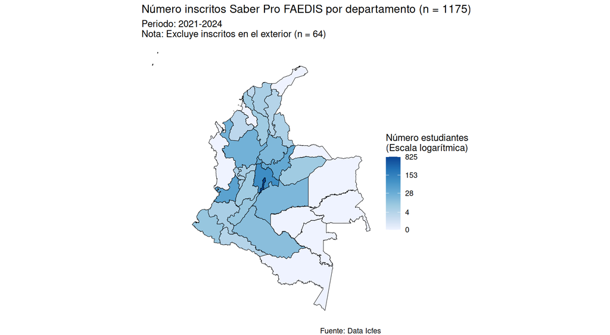

Figura 1: Resultado final de un mapa coroplético elaborado con `sf` y `ggplot2` a partir de datos geoestadísticos en formato `.gpkg`

# El formato `.gpkg`

## Formato GeoPackage (`.gpkg`)

- Tradicionalmente, el formato más empleado en los Sistemas de Información Geográfica (SIG) fue el **Shapefile** (`.shp`), el cual presenta diversas limitaciones técnicas (Jachym 2017).
- El formato **GeoPackage (`.gpkg`)** surge para superar estas restricciones:
  - Almacena toda la información espacial (vectores, rásteres) y tablas de atributos asociadas dentro de un **único archivo**.
  - Por “debajo”, un archivo `.gpkg` es una base de datos **SQLite** ligera, autónoma y portable.
  - Es de naturaleza **abierta, no propietaria e independiente de plataforma**, utilizable sin licencias comerciales y con total soporte en R.

## Open Geospatial Consortium (OGC)

- La apertura e interoperabilidad del formato es impulsada por el **[Open Geospatial Consortium (OGC)](https://www.ogc.org/about/overview/)**:
  - Consorcio internacional sin fines de lucro fundado en 1994, compuesto por organizaciones gubernamentales, empresas y universidades.
  - Su misión es definir consensos técnicos y **estándares abiertos** para que la información geoespacial sea accesible, interoperable y reutilizable.
- El estándar oficial **[OGC GeoPackage](https://www.ogc.org/standards/geopackage/)** garantiza la transferencia fluida de datos espaciales entre diferentes aplicaciones SIG, bases de datos y lenguajes de programación.

## Fuentes cartográficas en Colombia

Existen 2 plataformas oficiales para consultar y descargar información geográfica de Colombia en formatos abiertos como `.gpkg`:

1. **[Geoportal del Departamento Administrativo Nacional de Estadística (DANE)](https://geoportal.dane.gov.co/servicios/descarga-y-metadatos/datos-geoestadisticos/)**:
   - Ofrece el **Marco Geoestadístico Nacional (MGN)** para referenciar datos estadísticos con su ubicación territorial (departamentos, municipios, cabeceras, centros poblados).
   - De allí proviene el archivo departamental utilizado en esta sesión.
2. **[Portal de información geoespacial - Colombia en Mapas](https://www.colombiaenmapas.gov.co/inicio/)**:
   - Administrado por el Instituto Geográfico Agustín Codazzi (IGAC) junto con la Infraestructura Colombiana de Datos Espaciales (ICDE).
   - Centraliza y permite explorar capas temáticas geoespaciales de entidades públicas en formatos abiertos.

# Importación de datos en formato `.gpkg`

## Importar datos espaciales

```r
# Cargar paquetes ----
library(sf)

# Importar datos espaciales ----
col_dpto_sf <- read_sf(
  dsn = "data/nivel-departamento_version-mgn-2025_geopackage.gpkg"
)

col_dpto_sf
```

```
Simple feature collection with 33 features and 8 fields
Geometry type: MULTIPOLYGON
Dimension:     XY
Bounding box:  xmin: -81.73562 ymin: -4.229406 xmax: -66.84722 ymax: 13.39473
Geodetic CRS:  WGS 84
# A tibble: 33 × 9
   dpto_ccdgo dpto_cnmbr   dpto_ano_c dpto_act_a dpto_narea dpto_nano shape_Leng
   <chr>      <chr>             <int> <chr>           <dbl>     <int>      <dbl>
 1 05         ANTIOQUIA          1886 Constituc…     62789.      2025      21.5
 2 08         ATLÁNTICO          1910 Ley 21 de…      3324.      2025       2.71
 3 11         BOGOTÁ, D.C.       1538 Constituc…      1621.      2025       3.76
 4 13         BOLÍVAR            1886 Constituc…     26681.      2025      16.4
 5 15         BOYACÁ             1886 Constituc…     23073.      2024      16.0
 6 17         CALDAS             1905 11 de Abr…      7422.      2025       6.66
 7 18         CAQUETÁ            1981 Ley 78 de…     92709.      2024      21.2
 8 19         CAUCA              1857 15 de jun…     31261.      2025      14.0
 9 20         CESAR              1967 Ley 25  2…     22498.      2025      12.7
10 23         CÓRDOBA            1951 Ley 9 del…     25083.      2025       9.71
# ℹ 23 more rows
# ℹ 2 more variables: shape_Area <dbl>, geom <MULTIPOLYGON [°]>
```

- La función `read_sf()` del paquete `sf` utiliza el parámetro `dsn` (*Data Source Name*) para especificar la ruta del archivo `.gpkg`.

## Estructura de un objeto `sf`

- El paquete `sf` implementa el estándar internacional **Simple Features** del OGC.
- Un objeto `sf` es en esencia una `tibble` de R extendida con capacidades geográficas:
  1. **Encabezado de metadatos espaciales**:
     - `Simple feature collection`: número de geometrías (*features*, $33$) y atributos (*fields*, $8$).
     - `Geometry type`: `MULTIPOLYGON` (adecuado para departamentos con fragmentos territoriales discontinuos o islas).
     - `Dimension`: `XY` (coordenadas de longitud y latitud en 2 dimensiones).
     - `Bounding box`: caja delimitadora de coordenadas extremas (`xmin`, `ymin`, `xmax`, `ymax`).
     - `Geodetic CRS`: Sistema de Referencia de Coordenadas (`WGS 84`).

## Estructura de un objeto `sf`

- Un objeto `sf` es en esencia una `tibble` de R extendida con capacidades geográficas:
  2. **Tabla de datos**:
     - Columnas tradicionales de atributos no espaciales.
     - Columna especial de lista (**geometry list-column**, `geom`) con clase `<MULTIPOLYGON [°]>` que contiene las secuencias de coordenadas en grados decimales.

       **Nota**

       Para profundizar en los fundamentos conceptuales de los sistemas de coordenadas y la estructura cartográfica de un objeto `sf`, puedes consultar (Lovelace et al. 2025, cap. 2).
  - Al ser una `tibble`, un objeto `sf` se puede manipular directamente con las funciones conocidas del `tidyverse` (`select()`, `left_join()`, `mutate()`) y visualizarse de forma integrada con `ggplot2`.

## Importar variables no espaciales

```r
# Importar variables no espaciales ----
resultado_saber_pro_ajustado <- read_rds(
  file = "data/2021-2024_saber-pro-genericas_faedis_ajustado.rds"
)

resultado_saber_pro_ajustado
```

```
# A tibble: 1,239 × 21
     ano estu_consecutivo estu_genero estu_semestrecursa fami_estratovivienda
   <int> <chr>            <fct>       <ord>              <ord>
 1  2021 EK202120262469   M           09                 Estrato 3
 2  2021 EK202120116785   M           09                 Estrato 4
 3  2021 EK202120116868   M           09                 Estrato 5
 4  2021 EK202120116831   M           09                 Estrato 4
 5  2021 EK202120116814   F           09                 Estrato 2
 6  2021 EK202120117053   F           09                 Estrato 2
 7  2021 EK202120262258   F           08                 Estrato 3
 8  2021 EK202120262692   F           09                 Estrato 2
 9  2021 EK202120117033   F           08                 <NA>
10  2021 EK202120117014   F           08                 Estrato 3
# ℹ 1,229 more rows
# ℹ 16 more variables: fami_educacionmadre <ord>, fami_educacionpadre <ord>,
#   estu_exterior <chr>, estu_cod_depto_presentacion <chr>,
#   estu_depto_presentacion <chr>, estu_cod_mcpio_presentacion <chr>,
#   estu_mcpio_presentacion <chr>, estu_snies_prgmacademico <int>,
#   estu_prgm_academico <chr>, mod_competen_ciudada_punt <dbl>,
#   mod_comuni_escrita_punt <dbl>, mod_ingles_punt <dbl>, …
```

## Seleccionar variables y contar observaciones

```r
# Seleccionar ----
col_dpto_sf <- col_dpto_sf |>
  select(
    dpto_ccdgo,
    dpto_cnmbr,
    geom
  )

# Contar ----
resultado_saber_pro_ajustado <- resultado_saber_pro_ajustado |>
  count(
    estu_cod_depto_presentacion
  )
```

```
# A tibble: 25 × 2
   estu_cod_depto_presentacion     n
   <chr>                       <int>
 1 05                             24
 2 08                              3
 3 11                            825
 4 13                              8
 5 15                             34
 6 17                              6
 7 18                             14
 8 19                              6
 9 20                              4
10 23                              3
# ℹ 15 more rows
```

- `select()` conserva únicamente las columnas de interés en el objeto espacial (`dpto_ccdgo`, `dpto_cnmbr`, `geom`).
- `count()` agrupa y calcula la cantidad de estudiantes por departamento en la columna `n`. Los registros en el exterior quedan como `NA` en la última fila.

## Crear variables auxiliares

```r
# Variables auxiliares ----
n_na <- resultado_saber_pro_ajustado |>
  pull(n) |>
  last()

n_total <- resultado_saber_pro_ajustado |>
  pull(n) |>
  sum()
```

```
# A tibble: 2 × 2
  variable            valor
  <chr>               <int>
1 n_na (exterior)        64
2 n_total (inscritos)  1239
```

## Consolidar tablas y tratar valores ausentes

```r
# Consolidar tablas ----
col_dpto_saber_pro_n <- col_dpto_sf |>
  left_join(
    y = resultado_saber_pro_ajustado,
    by = join_by(
      dpto_ccdgo == estu_cod_depto_presentacion
    )
  )

# Limpiar valores ausentes ----
col_dpto_saber_pro_n <- col_dpto_saber_pro_n |>
  replace_na(
    replace = list(
      n = 0
    )
  )
```

```
Simple feature collection with 5 features and 3 fields
Geometry type: MULTIPOLYGON
Dimension:     XY
Bounding box:  xmin: -77.12783 ymin: 3.730633 xmax: -71.94885 ymax: 11.10537
Geodetic CRS:  WGS 84
# A tibble: 5 × 4
  dpto_ccdgo dpto_cnmbr       n                                             geom
  <chr>      <chr>        <int>                               <MULTIPOLYGON [°]>
1 05         ANTIOQUIA       24 (((-76.41355 8.873829, -76.40465 8.851953, -76.…
2 08         ATLÁNTICO        3 (((-74.84946 11.09778, -74.84938 11.09754, -74.…
3 11         BOGOTÁ, D.C.   825 (((-74.05361 4.832917, -74.0536 4.832947, -74.0…
4 13         BOLÍVAR          8 (((-76.1747 9.398572, -76.17467 9.398569, -76.1…
5 15         BOYACÁ          34 (((-72.18436 7.028938, -72.18409 7.028932, -72.…
```

- `left_join()` conserva los 33 departamentos de `col_dpto_sf` vinculando la columna `n`.
- `replace_na(replace = list(n = 0))` sustituye los `NA` por `0` en aquellos departamentos sin estudiantes registrados.

## Inspeccionar datos consolidados

```r
# Inspeccionar datos ----
glimpse(col_dpto_saber_pro_n)
```

```
Rows: 33
Columns: 4
$ dpto_ccdgo <chr> "05", "08", "11", "13", "15", "17", "18", "19", "20", "23",…
$ dpto_cnmbr <chr> "ANTIOQUIA", "ATLÁNTICO", "BOGOTÁ, D.C.", "BOLÍVAR", "BOYAC…
$ geom       <MULTIPOLYGON [°]> MULTIPOLYGON (((-76.41355 8..., MULTIPOLYGON (…
$ n          <int> 24, 3, 825, 8, 34, 6, 14, 6, 4, 3, 102, 0, 10, 0, 6, 19, 10…
```

- `col_dpto_saber_pro_n` queda listo con 33 observaciones y las 4 variables necesarias: `dpto_ccdgo`, `dpto_cnmbr`, `geom` y `n`.

# Visualización de datos geoespaciales

## Datos, mapeo y capas

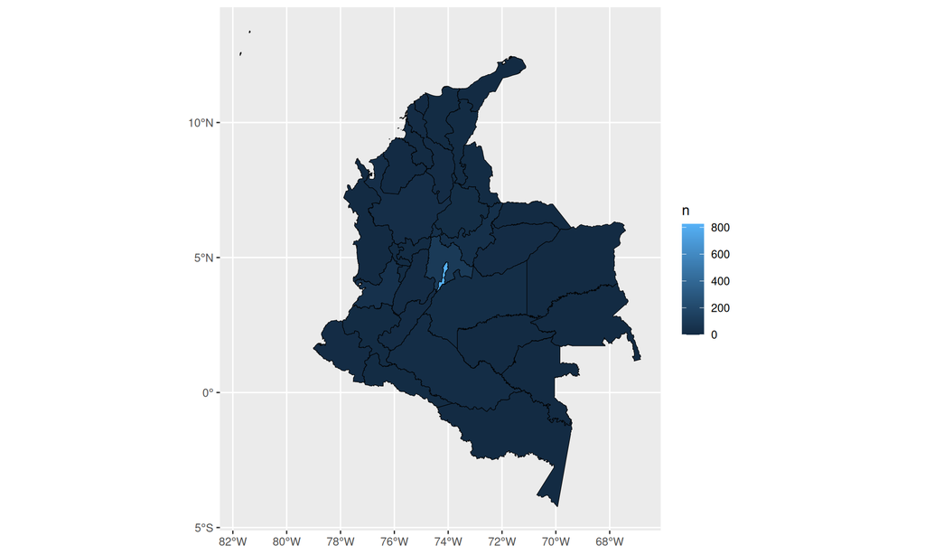

Representación base del mapa coroplético utilizando `geom_sf()` con relleno según el número de estudiantes

```r
# Visualización ----
col_dpto_saber_pro_n |>
  ggplot() +
  geom_sf(
    mapping = aes(
      geometry = geom,
      fill = n
    ),
    color = "black"
  )
```

## Componentes de `geom_sf()`

- **`geom_sf()`**: geometría especializada de `ggplot2` para visualizar objetos `sf`.
- **`geometry = geom`**: atributo estético que contiene la información geográfica del objeto (las secuencias de coordenadas).
- **Proyección de coordenadas**: `geom_sf()` incorpora automáticamente `coord_sf()`, asegurando que los polígonos se proyecten respetando el Sistema de Referencia de Coordenadas (CRS) sin distorsionar proporciones.
- **`fill = n`**: mapeo estético dependiente de los datos asignado al relleno interior de cada departamento.
- **`color = "black"`**: parámetro fijo fuera de `aes()` que delinea las fronteras departamentales con un contorno negro constante.

## El problema del valor atípico (*outlier*)

- Al observar el mapa base, se evidencia una limitación visual:
  - Bogotá D.C. registra **$825$** inscritos.
  - La mayoría de los demás departamentos tienen valores notablemente menores ($0$ en Guaviare, $3$ en Córdoba, $6$ en Cauca, $24$ en Antioquia, $34$ en Boyacá).
- En una **escala lineal convencional**, la distancia entre $0$ y $825$ comprime todos los valores bajos hacia el extremo inferior de la paleta.
- Como resultado, casi todos los departamentos presentan el mismo tono idéntico e indistinguible, impidiendo percibir diferencias relativas.

## Escala logarítmica y el caso del cero

- La **escala lineal** mide incrementos aditivos ($+10, +20, +30$).
- La **escala logarítmica** mide órdenes de magnitud multiplicativos ($\times 10, \times 100, \times 1000$).
- **Restricción matemática**: $\log_e(0)$ no está definido ($\log_e(0) \to -\infty$). Como hay departamentos con $n = 0$, no se puede aplicar directamente $\log_e(x)$.
- **Solución con `log1p`**: la transformación $\log_e(x + 1)$ garantiza que:
  $$\log_e(0 + 1) = \log_e(1) = 0$$
- **Función inversa `expm1`**: para recuperar las unidades originales y construir las marcas de la leyenda:
  $$y = \log_e(x + 1) \iff x = e^y - 1$$

## Escala lineal vs escala logarítmica

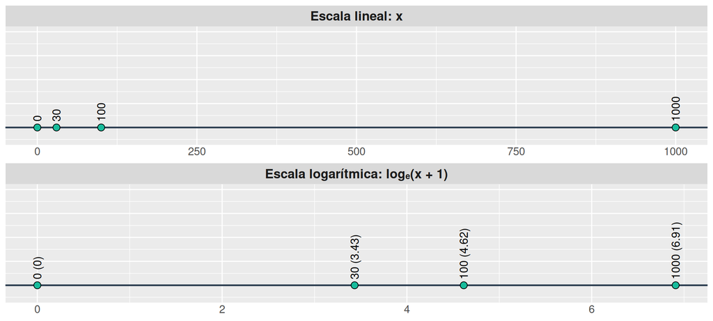

Figura 2: Comparación gráfica entre la distribución de valores en una escala lineal (superior) y una escala logarítmica transformada con $\log_e(x + 1)$ (inferior)

## Escala logarítmica

**Nota**

Para una explicación conceptual intuitiva y visual sobre los logaritmos y su utilidad al visualizar órdenes de magnitud, puedes consultar el video [Logarithms, Clearly Explained](https://youtu.be/VSi0Z04fWj0?si=7jzQYZtubEtJNPvx) del canal [StatQuest with Josh Starmer](https://www.youtube.com/@statquest).

- La transformación $\log_e(x + 1)$ permite discriminar visualmente departamentos con pocas observaciones sin perder la magnitud relativa del valor máximo.

## Variables auxiliares y cortes (`breaks`)

```r
# Variables auxiliares ----
## Mínimo y máximo ----
n_min <- col_dpto_saber_pro_n |>
  pull(n) |>
  min()

n_max <- col_dpto_saber_pro_n |>
  pull(n) |>
  max()

## Breaks ----
breaks <- seq.int(
  from = log1p(n_min),
  to = log1p(n_max),
  length.out = 5
) |>
  expm1() |>
  round()

breaks
```

```
[1]   0   4  28 153 825
```

- `seq.int()` genera 5 puntos equidistantes en el espacio logarítmico entre `log1p(0)` y `log1p(825)`.
- `expm1()` devuelve los valores a la escala natural
- `round()` genera números enteros limpios para las marcas de la leyenda.

## Aplicación de la escala de color

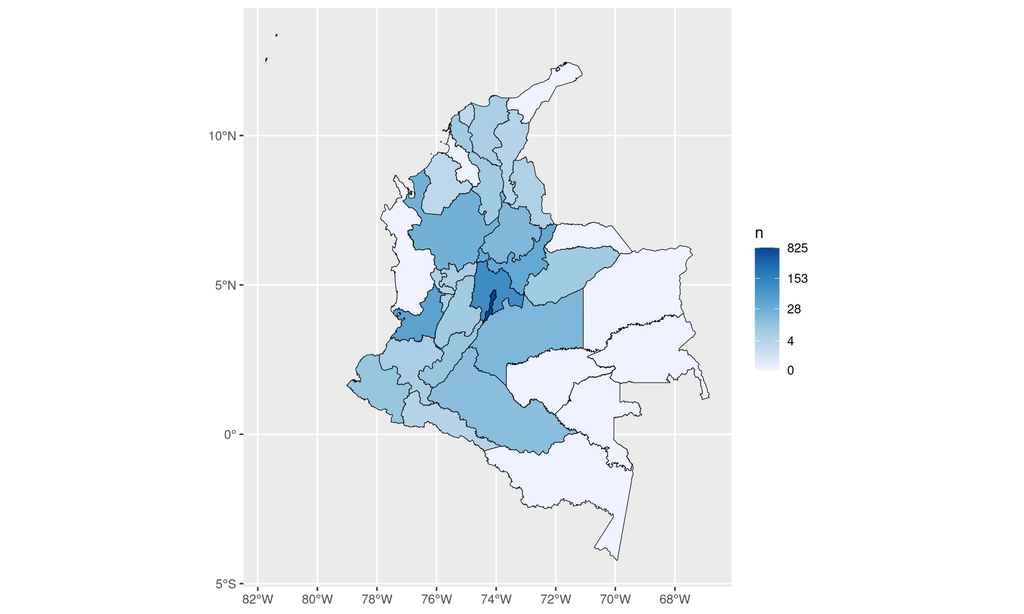

```r
col_dpto_saber_pro_n |>
  ggplot() +
  geom_sf(
    mapping = aes(
      geometry = geom,
      fill = n
    ),
    color = "black"
  ) +
  scale_fill_distiller(
    palette = "Blues",
    direction = 1,
    transform = "log1p",
    breaks = breaks
  )
```

- `palette = "Blues"`: aplica una paleta secuencial de ColorBrewer.
- `direction = 1`: orienta la paleta de modo que mayor cantidad corresponda a un azul más oscuro.
- `transform = "log1p"` y `breaks = breaks`: distribuyen el color en escala logarítmica con marcas legibles.

## Aplicación de etiquetas informativas

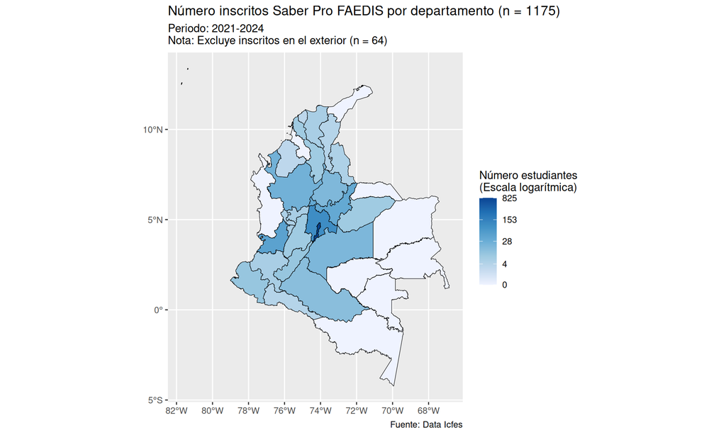

```r
col_dpto_saber_pro_n |>
  ggplot() +
  geom_sf(
    mapping = aes(
      geometry = geom,
      fill = n
    ),
    color = "black"
  ) +
  scale_fill_distiller(
    palette = "Blues",
    direction = 1,
    transform = "log1p",
    breaks = breaks
  ) +
  labs(
    fill = str_glue(
      "Número estudiantes
  (Escala logarítmica)"
    ),
    title = str_glue(
      "Número inscritos Saber Pro FAEDIS por departamento (n = {n_total - n_na})"
    ),
    subtitle = str_glue(
      "Periodo: 2021-2024
    Nota: Excluye inscritos en el exterior (n = {n_na})"
    ),
    caption = "Fuente: Data Icfes"
  )
```

- `str_glue()` permite intercalar variables de R dentro de llaves `{ }` calculando dinámicamente subtotales.

## Aplicación del tema

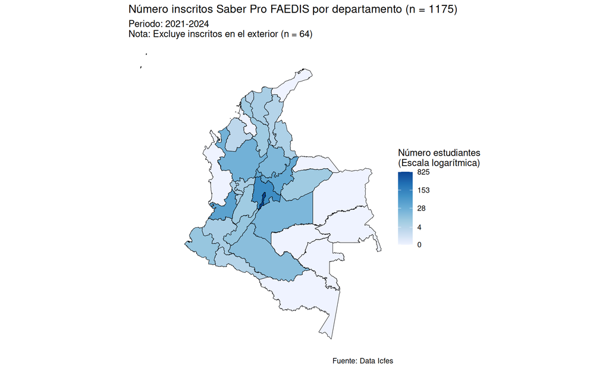

```r
col_dpto_saber_pro_n |>
  ggplot() +
  geom_sf(
    mapping = aes(
      geometry = geom,
      fill = n
    ),
    color = "black"
  ) +
  scale_fill_distiller(
    palette = "Blues",
    direction = 1,
    transform = "log1p",
    breaks = breaks
  ) +
  labs(
    fill = str_glue(
      "Número estudiantes
  (Escala logarítmica)"
    ),
    title = str_glue(
      "Número inscritos Saber Pro FAEDIS por departamento (n = {n_total - n_na})"
    ),
    subtitle = str_glue(
      "Periodo: 2021-2024
    Nota: Excluye inscritos en el exterior (n = {n_na})"
    ),
    caption = "Fuente: Data Icfes"
  ) +
  theme_void()
```

- `theme_void()` remueve cuadrículas cartesianas, ejes y fondos innecesarios, enfocando la atención exclusivamente en las formas geográficas y la intensidad del color.

Gracias

# Referencias

Jachym, Cepicky. 2017. *Shapefile must die!* http://switchfromshapefile.org/.

Lovelace, Robin, Jakub Nowosad, y Jannes Münchow. 2025. *Geocomputation with R*. 2.ª ed. Chapman & Hall/CRC the R series. CRC Press, Taylor & Francis Group. https://r.geocompx.org/.